# Visualización avanzada con ggplot2 en R

Isaac Zainea

2024-09-18

# Introducción

En este documento exploraremos técnicas avanzadas de visualización de datos utilizando `ggplot2`. Nos enfocaremos en:

1. Gráficos de barras apiladas y facetados.
2. Mapas de calor.
3. Gráficos de densidad.
4. Análisis de correlación utilizando gráficos de dispersión.

Para estos ejemplos, usaremos el dataset del Titanic. A continuación, mostramos cómo se cargan y limpian los datos antes de comenzar con las visualizaciones.

```r
# Cargar librerías necesarias
library(ggplot2)
library(dplyr)
```

# Cargar y Limpiar el Dataset

```r
# Cargar el dataset Titanic
# Aquí asumimos que el dataset titanic ya está disponible como dataframe
# Cambia este bloque si necesitas cargar los datos desde un archivo

library(readr)
titanic <- read_csv("Datos/titanic.csv")
# Limpiar los datos: Eliminamos los valores NA en las columnas importantes
titanic <- titanic %>%
  filter(!is.na(Age), !is.na(Fare), !is.na(Survived), !is.na(Sex), !is.na(Pclass))

# Ver una muestra del dataset limpio
head(titanic)
```

```
## # A tibble: 6 × 12
##   PassengerId Survived Pclass Name    Sex     Age SibSp Parch Ticket  Fare Cabin
##         <dbl>    <dbl>  <dbl> <chr>   <chr> <dbl> <dbl> <dbl> <chr>  <dbl> <chr>
## 1           1        0      3 Braund… male     22     1     0 A/5 2…  7.25 <NA>
## 2           2        1      1 Cuming… fema…    38     1     0 PC 17… 71.3  C85
## 3           3        1      3 Heikki… fema…    26     0     0 STON/…  7.92 <NA>
## 4           4        1      1 Futrel… fema…    35     1     0 113803 53.1  C123
## 5           5        0      3 Allen,… male     35     0     0 373450  8.05 <NA>
## 6           7        0      1 McCart… male     54     0     0 17463  51.9  E46
## # ℹ 1 more variable: Embarked <chr>
```

# 1. Gráfico de Barras Apiladas con Facetado

Los gráficos de barras apiladas permiten comparar múltiples categorías dentro de una sola variable. Aquí observaremos la distribución de pasajeros por clase (Pclass) y sexo (Sex), con un facetado adicional que indica si sobrevivieron o no.

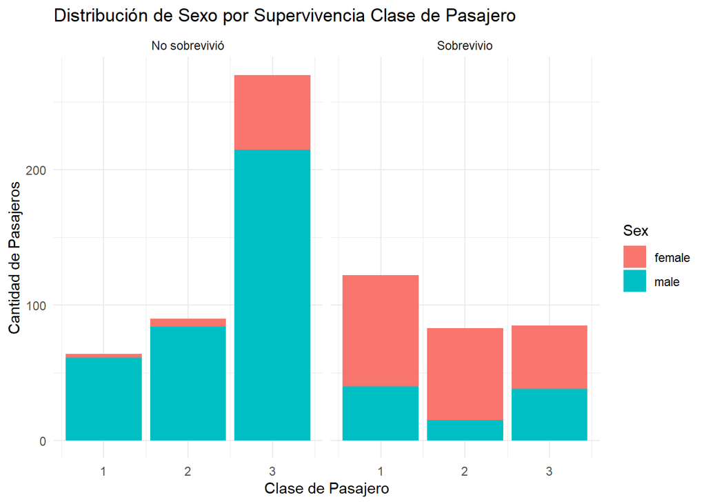

```r
ggplot(titanic, aes(x = Pclass, fill = Sex)) +
  geom_bar(position = "stack") +
  labs(title = "Distribución de Sexo por Supervivencia Clase de Pasajero",
       x = "Clase de Pasajero",
       y = "Cantidad de Pasajeros") +
  facet_wrap(~ Survived,labeller = as_labeller(c(`0`="No sobrevivió",`1` ="Sobrevivio"))) +
  theme_minimal()
```

**Interpretación**: El facetado nos permite observar diferencias en la supervivencia según el sexo y la clase de pasajero.

# 2. Mapa de Calor

El mapa de calor es útil para visualizar la relación entre dos variables continuas. Aquí veremos cómo la edad y el precio del pasaje se relacionan utilizando `geom_bin2d`.

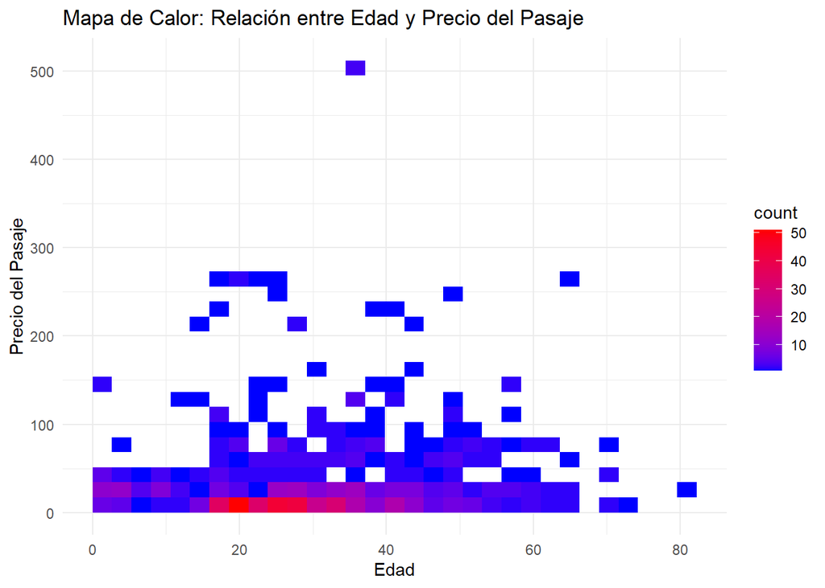

```r
ggplot(titanic, aes(x = Age, y = Fare)) +
  geom_bin2d(bins = 30) +
  scale_fill_gradient(low = "blue", high = "red") +
  labs(title = "Mapa de Calor: Relación entre Edad y Precio del Pasaje",
       x = "Edad",
       y = "Precio del Pasaje") +
  theme_minimal()
```

**Interpretación**: Las áreas más rojas indican una mayor densidad de observaciones. En este gráfico, se puede observar que la mayoría de los pasajeros eran jóvenes y pagaron precios de boletos más bajos.

# 3. Gráfico de Densidad

Los gráficos de densidad nos permiten observar la distribución de una variable continua. En este caso, analizamos la distribución de la edad según si los pasajeros sobrevivieron o no.

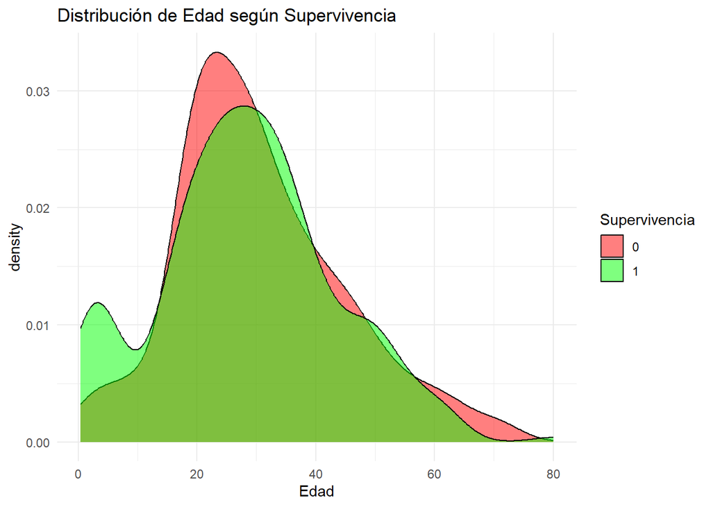

```r
ggplot(titanic, aes(x = Age, fill = factor(Survived))) +
  geom_density(alpha = 0.5) +
  labs(title = "Distribución de Edad según Supervivencia",
       x = "Edad",
       fill = "Supervivencia") +
  scale_fill_manual(values = c("red", "green")) +
  theme_minimal()
```

# 4. Gráfico de Dispersión y Análisis de Correlación

Finalmente, utilizamos un gráfico de dispersión para ver la relación entre la edad y el precio del pasaje, añadiendo una línea de tendencia con `geom_smooth`.

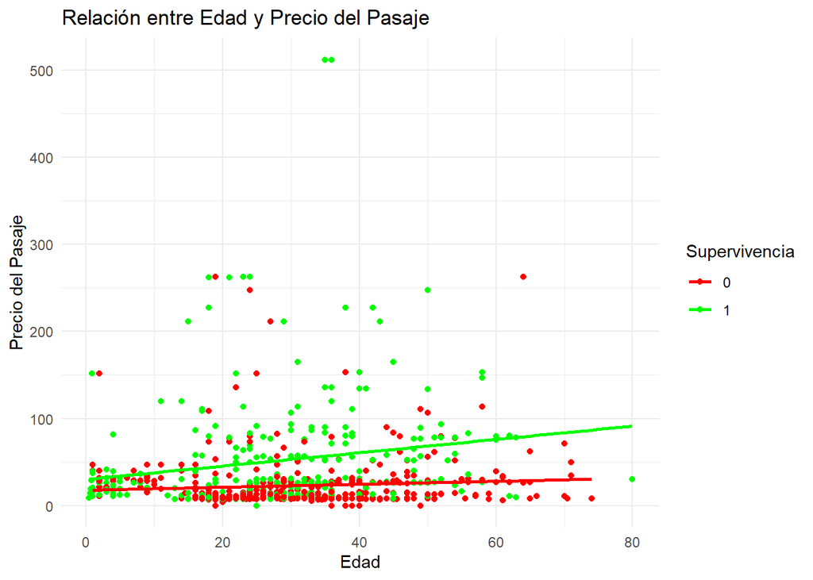

```r
ggplot(titanic, aes(x = Age, y = Fare, color = factor(Survived))) +
  geom_point() +
  geom_smooth(method = "lm", se = FALSE) +
  labs(title = "Relación entre Edad y Precio del Pasaje",
       x = "Edad",
       y = "Precio del Pasaje",
       color = "Supervivencia") +
  scale_color_manual(values = c("red", "green")) +
  theme_minimal()
```

**Interpretación**: Podemos observar que no hay una fuerte correlación entre la edad y el precio del pasaje. La línea de tendencia nos da una idea de la dirección general, pero la relación parece ser débil.

# Conclusión

En este documento hemos explorado visualizaciones avanzadas usando `ggplot2`, cada una con un propósito distinto para mejorar el análisis exploratorio de datos. Estos métodos son valiosos para identificar patrones y relaciones que no son evidentes a simple vista.